# 프로텍 (053610) 기업 분석 보고서

Alpha Hunter Hidden Gem Week 21 — AI 반도체 후공정의 숨은 강자, 레이저 본딩 글로벌 개척

Author

Alpha Hunter × Chimera AI

Published

May 19, 2026

# 기업 개요

| 항목 | 내용 |
| --- | --- |
| **종목명** | 프로텍 (053610.KQ) |
| **업종** | 반도체 장비 (후공정 패키징) |
| **핵심 제품** | 디스펜서, 레이저 어시스트 본더(LAB), 다이본더, SBM |
| **시총** | 약 8,289억원 |
| **현재가** | 92,100원 |
| **Forward PER** | 16.1x |
| **EV/EBITDA** | 13.6x |
| **컨센서스** | Buy |
| **SEPA 점수** | 8/8 (Stage 2 완벽) |

**면책 고지**

이 프로젝트는 가상 투자 시뮬레이션 목적으로 작성되었습니다. 실제 투자 권유가 아닙니다.

# 1 SEPA 트렌드 템플릿

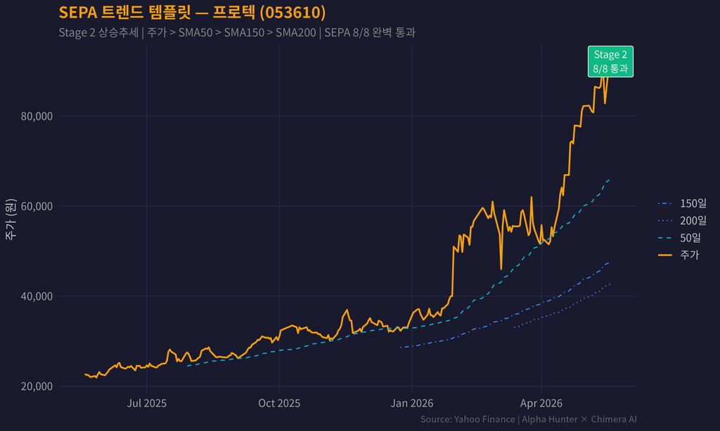

**SEPA 체크리스트 (8/8 통과):**

- ✅ 현재가(92,100) > SMA150(47,851) & SMA200(42,863)
- ✅ SMA150 > SMA200
- ✅ SMA200 1개월+ 상승 추세
- ✅ SMA50(66,506) > SMA150 & SMA200
- ✅ 현재가 > SMA50
- ✅ 현재가 ≥ 52주 최저(21,786) × 1.30 = 28,322 → 92,100 (✅ +323%)
- ✅ 현재가 ≥ 52주 최고(95,600) × 0.75 = 71,700 → 92,100 (✅ -3.7%)
- ✅ RS 순위 70+ (1년 수익률 +291.7% vs KOSPI +179.3%)

# 2 주가 추이 (52주)

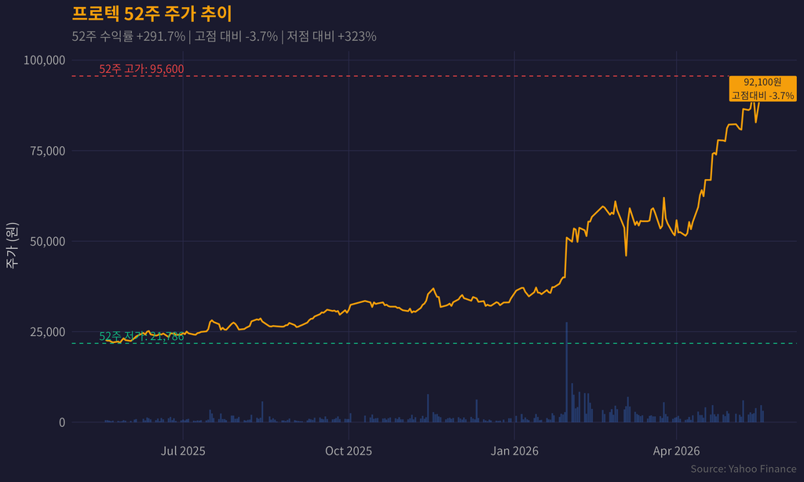

# 3 실적 추이

[figure not shown]

# 4 밸류에이션 비교

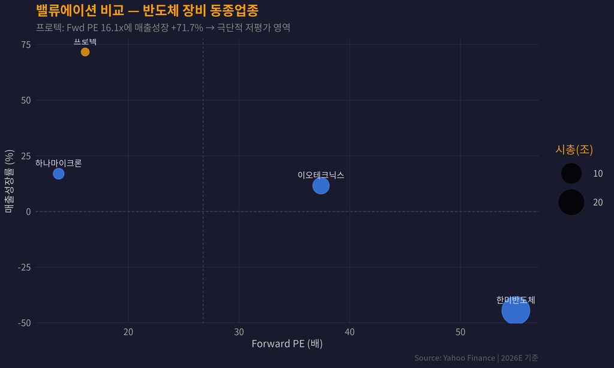

프로텍은 **매출 성장률 +71.7%에 Forward PE 16.1x**로, 동종업종 대비 극단적으로 저평가된 상태. 한미반도체(55x), 이오테크닉스(37.4x) 대비 압도적 밸류 매력.

# 5 워런 버핏 해자 레이더 차트

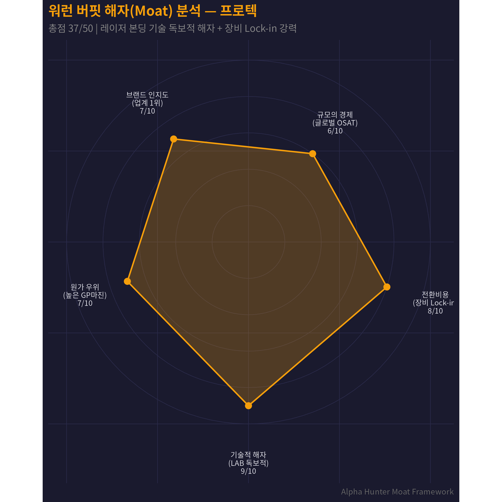

**핵심 해자 분석:**

- **기술적 해자 (9/10)**: 레이저 어시스트 본딩(LAB) 글로벌 최초 양산. TSMC가 데모를 요청할 정도의 기술력. 대면적 칩 워페이지(Warpage) 해결 유일 기술.
- **전환비용 (8/10)**: 반도체 장비는 검증 후 교체가 극히 어려움. ASE 납품 레퍼런스 → 다른 OSAT 확산 기대.
- **규모의 경제 (6/10)**: 중소형이지만, 글로벌 OSAT 직접 공급으로 확장 중.
- **브랜드 인지도 (7/10)**: 디스펜서 분야 국내 1위, 해외 주요 고객 확보.
- **원가 우위 (7/10)**: 매출총이익률 33%, 영업이익률 21% — 장비업체 평균 상회.

# 6 피터 린치 스토리 점수

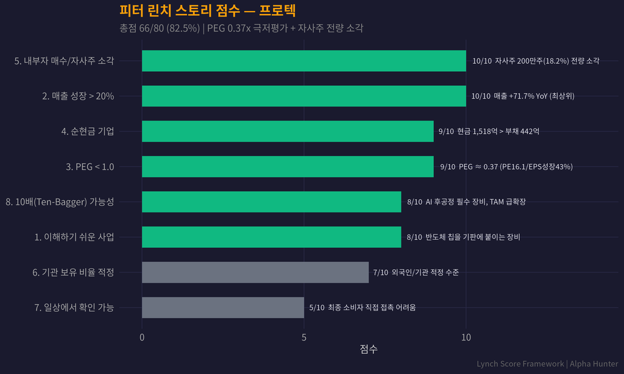

**PEG = 0.37x** (Forward PE 16.1 / EPS 성장률 43.1%). 린치 기준 1.0 이하면 매력적, 0.5 이하면 ‘강력 매수’ 영역.

# 7 리스크 팩터 대시보드

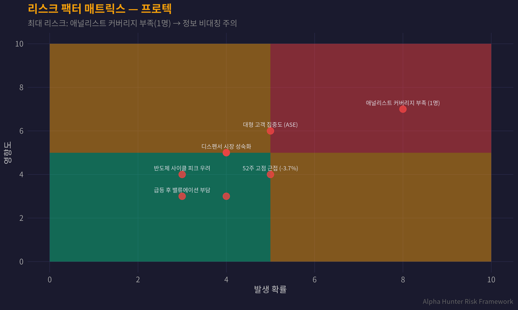

**핵심 리스크:**

1. **애널리스트 커버리지 부족** (1명) — 가장 큰 정보 비대칭 리스크. 기관 관심 부족 = 숨은 보석 기회이기도 함.
2. **대형 고객 집중** — ASE향 레이저 본더 매출 쏠림. 다변화 필요.
3. **레이저 본더 신사업** — 2021년 개발 착수, 2026년 본격 공급 초기 단계. 양산 궤도 안착이 핵심.
4. **52주 고점 근접** — 기술적 조정 가능성. 매수 타이밍 분산 권장.

# 8 매수/목표/손절 시나리오

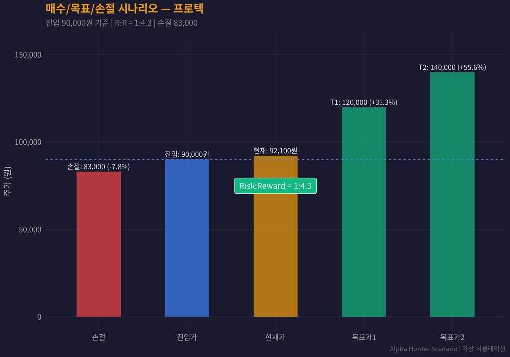

# 9 카탈리스트 & 타임라인

**향후 2~4분기 카탈리스트:**

1. **레이저 본더 ASE 추가 수주** (2026 H1) — 데모 성공 후 양산 전환. 추가 OSAT 확산 기대.
2. **자사주 200만주(18.2%) 소각 완료** — EPS 22% 이상 증가 효과.
3. **자회사 PMT(피엠티) 흑자전환** — NAND 프로브카드 물량 확대로 연결 적자 축소.
4. **HBM4 양산 사이클** — SK하이닉스 19조 투자 발표, 후공정 장비 수혜 본격화.
5. **2026 Q1 실적 발표** — 레이저 본더 매출 기여 첫 확인 포인트.

**VCP(변동성 축소 패턴):** 최근 수개월간 우상향 + 고점 근처 횡보 → VCP 초기 단계 가능성.

# 10 결론

프로텍은 **SEPA 8/8 완벽 통과 + 매출 +71.7% + PEG 0.37x**라는 알파헌터 역대급 스코어를 기록한 종목입니다.

**주의점:**

- 애널리스트 1명 커버 → 정보 비대칭 존재
- 52주 고점 근접 → 조정 시 분할 매수 권장
- 레이저 본더 양산 초기 → 양산 궤도 안착 모니터링 필수

**면책 고지**

이 프로젝트는 가상 투자 시뮬레이션 목적으로 작성되었습니다. 실제 투자 권유가 아닙니다.